# DS-Projcet 201620857 문상혁

## 1) Define Data Analysis Topic

- 경기도 데이터센터에서 제공하는 2014~2018년도 경기도 소재의 여러 대학들의 졸업자들의 취업(진로)현황에 관한 데이터를 조사해본다. 학과(전공)들끼리 진로 방향의 유사성을 확인해보고, 연도별로 구분하여 또한 확인해 본다. 분석을 통해 앞선 졸업 선배들의 진로가 어떠했는지 확인해보고 또한 최근에 와서는 어떤 경향을 보이는지 확인해보고, 앞으로 졸업후 진로 방향도 고민, 계획해본다.

## 2) Design Data Analysis Process

#### A.How to get the dataset (data = sensor dataset)

- 데이터는 '경기데이터드림' 홈페이지에서 '졸업생의 취업현황(대학,전문대학)'을 통해 얻을 수 있었다. (https://data.gg.go.kr/portal/data/service/selectServicePage.do?page=1&rows=10&sortColumn=&sortDirection=&infId=VKDOA5CQIDEBP60JB37M24077503&infSeq=2&order=&loc=&searchWord=%EB%8C%80%ED%95%99&cateId=GG23#none)
- 데이터는 csv파일로 아주대학교 외에 경기도 소재의 여러 대학교들의 취업현황을2014~2018년도 졸업자들을 대상으로 한다.
- 원본 파일에는 다른 대학교 및, 회사의 종류(label B)- 진학(label C) - 입대자(laebl D) - 취업불가능(label E)등 Label A - Label AZ까지 여러 label이 존재하지만, 해당 label에 인원수가 0에 가까운 매우 작은 label이 많아 총 4개의 label로 데이터를 다시 가공하였다.
- 수정된 csv파일의 label은 국내+해외취업자수, (대학원)진학자수, 기타인원수1(입대자+외국인유학생+건강보험직장가입제외), 기타인원수2 총 4개와 각 과의 정보를 나타내는 졸업자수, 취업률, 단과대학명, 학과명등이 있다.

#### B. Which algorithm to apply (e.g. clustering, classification, stochastic algorithm ..)

- 학과별 진학 방향(회사취직, 대학원 진학, 기타1, 기타2)의 유사성을 k-means clustering 기법을 통해 확인한다.
- 위의 기준을 통해 형성된 cluster내부 요소들끼리의 단과대학이 어느정도 일치하는지를 확인하여 형성된 cluster가 진로 방향이 비슷할 수 있는 단과대학의 일치도 확인을 통해 cluster가 어느정도 적절하게 형성되었는지 판단한다.

#### C. Which procedure to proceed

- 각 학과명(전공)을 x축으로, k-means clustering의 features의 합을 y축으로 하는 scatter 그래프를 통해 cluster 형성.
- 각 연도별(2014,2015,2016,2017,2018)에 따라 형성된 cluster를 비교.
- 전체 연도(2014~2018년 모든 데이터)에 따라 형성된 cluster를 비교.
- k=2부터 증가시켜서 형성되는 cluster의 형태를 분석
- 총 단과대학의수(간호대학, 정보통신대학, 경영대학... = 9개)일 때 k=9일 때 형성된 cluster에서 단과대학의 유사성을 계산하여 같은 단과대학일 경우 진로 방향이 유사할 수 있다는 가정을 통하여 cluster의 성능을 확인.

## 3)Implementation of your Data Analysis Task

```python
import numpy as np
import pandas as pd
import seaborn as sns
import matplotlib as mpl
import matplotlib.pyplot as plt

data = pd.read_csv("졸업생의취업현황(대학,전문대학)_수정.csv")
data
```

|  | 기준년도 | 학교종류명 | 설립구분명 | 학교명 | 단과대학명 | 학과명(전공) | 구분명 | 학과특성명 | 졸업자수 | 국내+해외 취업자수 | 진학자수 | 기타인원수1(입대자수+외국인유학생+건강보험직장가입제외대상자수) | 기타인원수2 | 취업률(%)[ J / [I - (K+L)] ] *100(%) |
| --- | --- | --- | --- | --- | --- | --- | --- | --- | --- | --- | --- | --- | --- | --- |
| 0 | 2018 | 대학교 | 사립 | 아주대학교 | 간호대학 | 간호학과 | 주간 | 일반과정 | 65 | 53 | 0 | 0 | 12 | 81.5 |
| 1 | 2018 | 대학교 | 사립 | 아주대학교 | 정보통신대학 | 전자공학과 | 주간 | 일반과정 | 250 | 163 | 39 | 1 | 44 | 77.6 |
| 2 | 2018 | 대학교 | 사립 | 아주대학교 | 경영대학 | e-비즈니스학과 | 주간 | 일반과정 | 47 | 34 | 0 | 0 | 13 | 72.3 |
| 3 | 2018 | 대학교 | 사립 | 아주대학교 | 경영대학 | 경영학과 | 주간 | 일반과정 | 165 | 102 | 5 | 0 | 45 | 63.8 |
| 4 | 2018 | 대학교 | 사립 | 아주대학교 | 경영대학 | 금융공학과 | 주간 | 일반과정 | 36 | 17 | 10 | 0 | 9 | 65.4 |
| ... | ... | ... | ... | ... | ... | ... | ... | ... | ... | ... | ... | ... | ... | ... |
| 171 | 2014 | 대학교 | 사립 | 아주대학교 _본교 | 공과대학 | 환경공학과 | 주간 | 일반과정 | 29 | 16 | 5 | 0 | 8 | 66.7 |
| 172 | 2014 | 대학교 | 사립 | 아주대학교 _본교 | 정보통신대학 | 미디어학과 | 주간 | 일반과정 | 104 | 69 | 9 | 0 | 26 | 72.6 |
| 173 | 2014 | 대학교 | 사립 | 아주대학교 _본교 | 정보통신대학 | 전자공학과 | 주간 | 일반과정 | 200 | 124 | 46 | 1 | 29 | 81.0 |
| 174 | 2014 | 대학교 | 사립 | 아주대학교 _본교 | 정보통신대학 | 정보컴퓨터공학과 | 주간 | 일반과정 | 143 | 87 | 42 | 0 | 14 | 86.1 |
| 175 | 2014 | 대학교 | 사립 | 아주대학교 _본교 | 사회과학대학 | 심리학과 | 주간 | 일반과정 | 60 | 20 | 22 | 0 | 18 | 52.6 |

176 rows × 14 columns

#### 1)전체 연도에 해당할 때, k = 2, 5, 10 ,20을 통해 형성되는 cluster

```
C:\Users\msh10\Desktop\학교\4학년 1학기\센서빅데이터\강의노트(코드)\Lecture12\Lecture12

     Test k-means (k = 2)
```

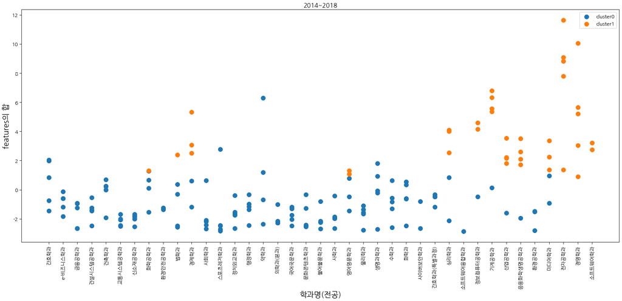

```
     Test k-means (k = 5)
```

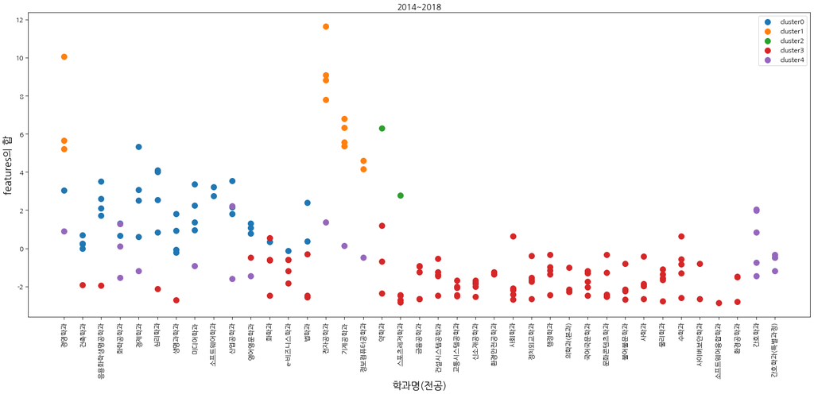

```
     Test k-means (k = 10)
```

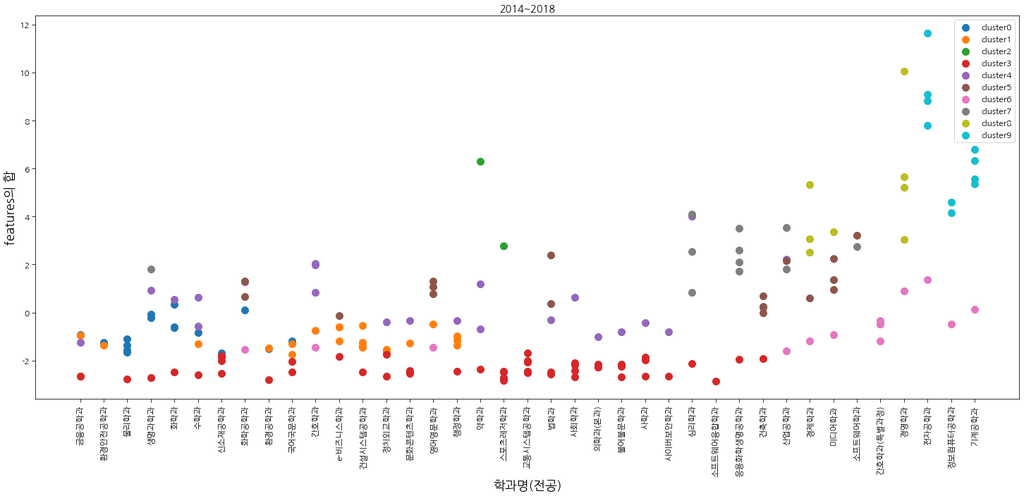

```
     Test k-means (k = 20)
```

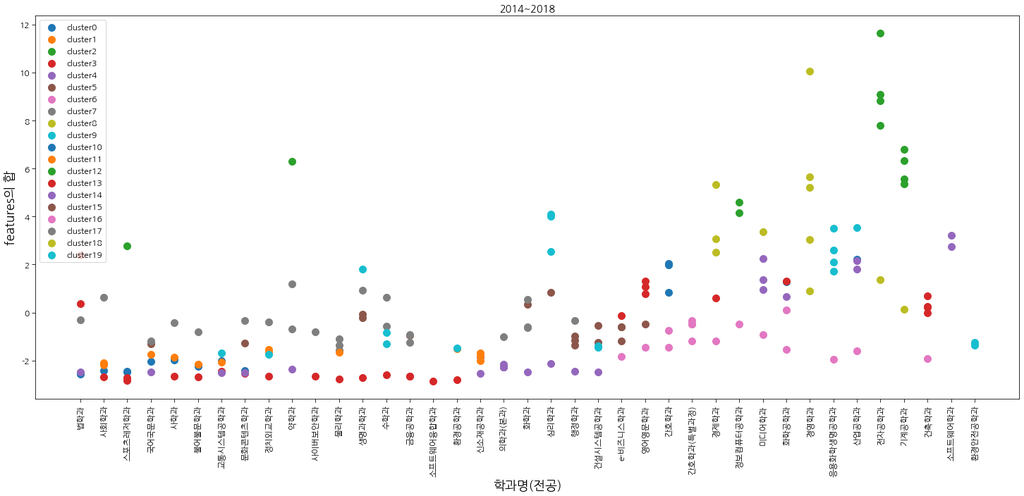

```python
"""projcet1~4는 각각 설명에 맞는 데이터 시각화를 위해 형성한 프로젝트 파일이어서 main 실행문만 조금 다를 뿐 projcet 파일과 코딩은 차이가
거의 없습니다."""
import project1
```

#### 2) 각 연도별에 따른 cluster 형성 (k=9)

```
c:\Users\msh10\Desktop\학교\4학년 1학기\센서빅데이터\강의노트(코드)\Lecture12\Lecture12
```

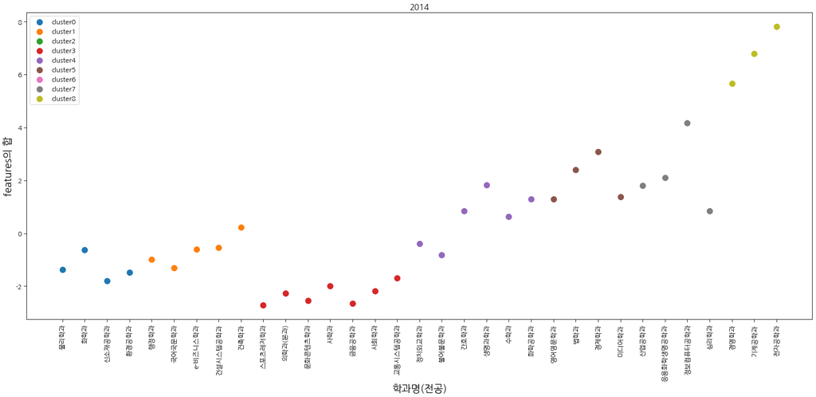

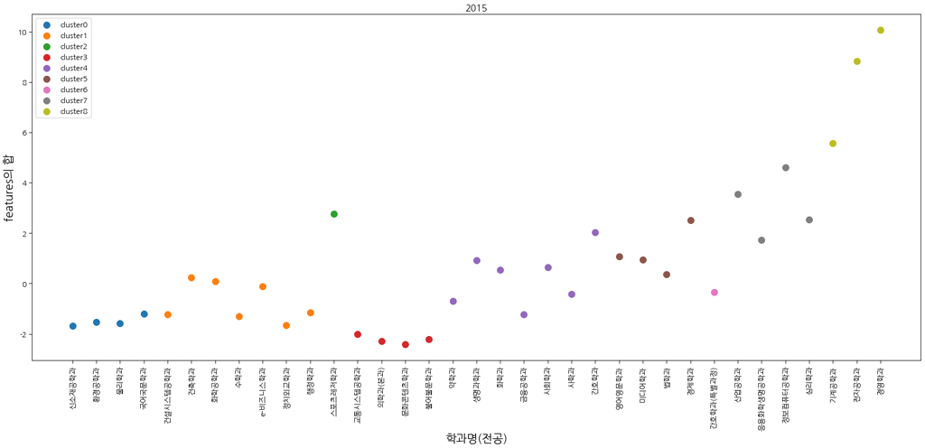

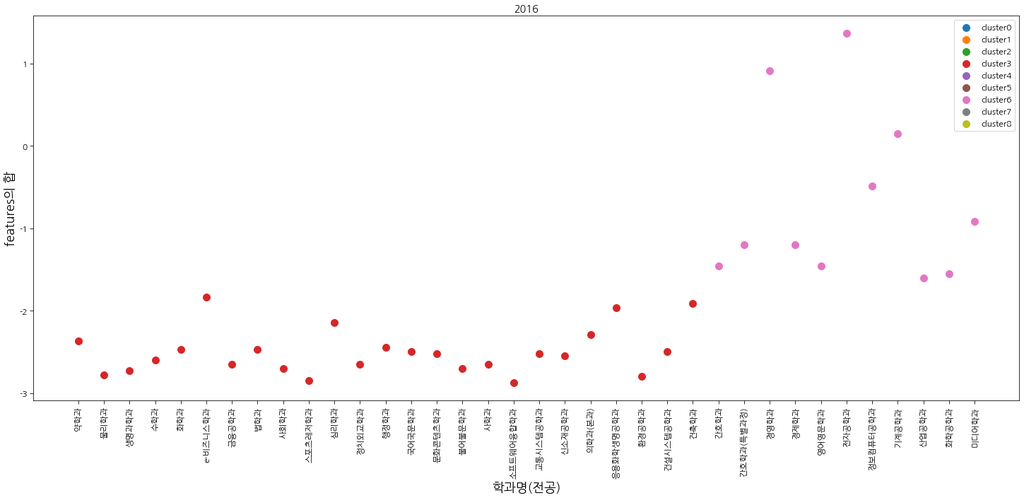

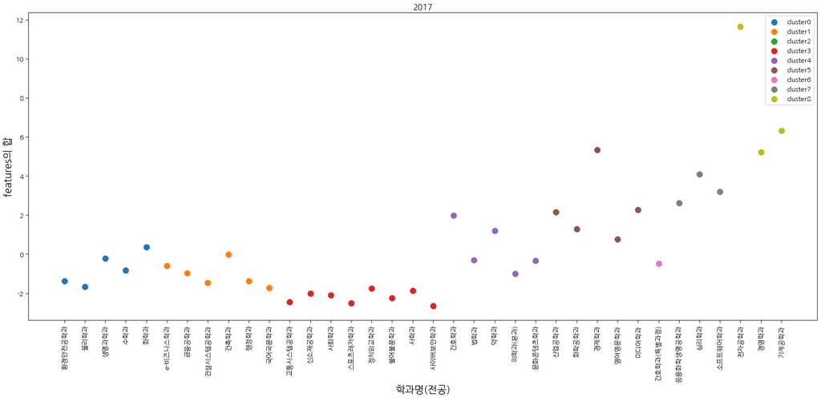

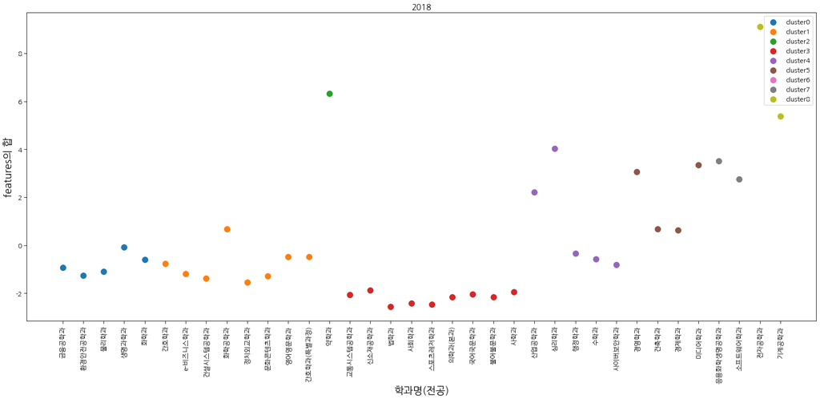

```python
import project2
```

## 4) Exploratory Data Analysis (=Data Visualization and Analysis)

#### 2) k=9 일 떄 각 연도별에 따른 cluster 분석

- csv파일을 보면 연도별로는 단과대학이 동일한것들 끼리 sort되어 순서대로 파일을 형성했음을 확인할 수 있다(label = 단과대학명). 따라서 연도별 그래프에서는 형성된 cluster가 y축의 features합 뿐만 아니라 x축의 학과(전공명)들 간의 간격이 작다면 같은 단과대학을 의미하므로 단과대학과 형성된 cluster간의 비교를 통해 cluster 성능을 유추해 볼 수 있다.
- 형성된 cluster를 보면 4-1)의 전체 연도에 따른 cluster를 형성했을 때 보다 x,y축이 가까울 수록 cluster가 형성된 것으로 보아, 더 정밀한 cluster가 형성되었다고 할 수 있다. 따라서 단과대학수와 k값을 유사하게 설정할수록 진로 방향이 어느정도 유사하다고 생각해 볼수 있다.

```python
import project3
```

```
c:\Users\msh10\Desktop\학교\4학년 1학기\센서빅데이터\강의노트(코드)\Lecture12\Lecture12

     Test k-means (k = 2)
0.1441085160009591

     Test k-means (k = 5)
0.1714114805128657

     Test k-means (k = 10)
0.18400546736405457

     Test k-means (k = 20)
0.180274526043865
```

## 5) Verification and Evaluation of your work

```python
import project4
```

```
c:\Users\msh10\Desktop\학교\4학년 1학기\센서빅데이터\강의노트(코드)\Lecture12\Lecture12
k= 2 each cluster of similarity
Cluster of size 137 with similarity of College type = 0.1430871618720481
Cluster of size 39 with similarity of College type = 0.14512987012987014
k= 5 each cluster of similarity
Cluster of size 39 with similarity of College type = 0.18353576248313092
Cluster of size 13 with similarity of College type = 0.19155354449472098
Cluster of size 2 with similarity of College type = 0.18308874912648498
Cluster of size 101 with similarity of College type = 0.15374947633012148
Cluster of size 21 with similarity of College type = 0.14512987012987014
k= 9 each cluster of similarity
Cluster of size 18 with similarity of College type = 0.39215686274509803
Cluster of size 26 with similarity of College type = 0.20718816067653276
Cluster of size 2 with similarity of College type = 0.19420289855072465
Cluster of size 53 with similarity of College type = 0.1665635951350237
Cluster of size 23 with similarity of College type = 0.15092805852865465
Cluster of size 17 with similarity of College type = 0.14586591596288187
Cluster of size 13 with similarity of College type = 0.140205646566748
Cluster of size 13 with similarity of College type = 0.1451589061345159
Cluster of size 11 with similarity of College type = 0.14512987012987014
k= 10 each cluster of similarity
Cluster of size 16 with similarity of College type = 0.425
Cluster of size 21 with similarity of College type = 0.19519519519519518
Cluster of size 2 with similarity of College type = 0.18218623481781376
Cluster of size 54 with similarity of College type = 0.1638616175783076
Cluster of size 22 with similarity of College type = 0.1488939740655988
Cluster of size 18 with similarity of College type = 0.14741398951925266
Cluster of size 14 with similarity of College type = 0.14015469201379183
Cluster of size 11 with similarity of College type = 0.14778682576795937
Cluster of size 8 with similarity of College type = 0.14443227455275648
Cluster of size 10 with similarity of College type = 0.14512987012987014
k= 20 each cluster of similarity
Cluster of size 11 with similarity of College type = 0.32727272727272727
Cluster of size 7 with similarity of College type = 0.37254901960784315
Cluster of size 2 with similarity of College type = 0.3368421052631579
Cluster of size 16 with similarity of College type = 0.2222222222222222
Cluster of size 15 with similarity of College type = 0.17176470588235293
Cluster of size 12 with similarity of College type = 0.17306707629288273
Cluster of size 9 with similarity of College type = 0.14827856025039124
Cluster of size 7 with similarity of College type = 0.14021421616358326
Cluster of size 8 with similarity of College type = 0.14087142475273992
Cluster of size 9 with similarity of College type = 0.14517543859649124
Cluster of size 5 with similarity of College type = 0.14079207920792078
Cluster of size 6 with similarity of College type = 0.14388996649620878
Cluster of size 10 with similarity of College type = 0.14073091659298556
Cluster of size 12 with similarity of College type = 0.14437984496124032
Cluster of size 8 with similarity of College type = 0.1452340060111636
Cluster of size 4 with similarity of College type = 0.14326241134751774
Cluster of size 7 with similarity of College type = 0.14681007538150395
Cluster of size 16 with similarity of College type = 0.13848571001047433
Cluster of size 3 with similarity of College type = 0.13851814443402352
Cluster of size 9 with similarity of College type = 0.14512987012987014
```

## 6) Conclude your data analysis project

- 다음 프로젝트를 통하여 수업시간에 배운 k-means clustering을 현실과 가까운 취업 관련 데이터에 적용해 봄으로써 더 깊은 이해와 발생하는 한계점 또한 생각할 수 있었다. 파악하려는 cluster들의 label에 해당하는 이론적인 cluster개수(실제의 총 단과대학의 수)와 비슷할 수록 clustering 기법을 통해 의미있는 경향성을 확인할 수 있다. 그러나, cluster를 형성하는 features들의 중요성이 정확하게 scaling 되는 점 또는 다른 clustering 기법을 통한 추가적인 적절성의 필요성 등을 통해서 데이터 분석의 결과를 맹신해서는 안된다는 생각도 할 수 있었다. 따라서 feature의 중요성을 더 적절히 반영할 수 있는 scaling 기법과 랜덤으로 clustering의 inital node를 설정했다 하더라도 왜곡 될 수 있으므로 이를 보완할 수 있는 기법등 clustering 기법에서 더 보완하고 생각해야 할 부분이 아직 많이 남았다고 생각한다.